# Tipos de filme de Sandra Bullock

## Agrupamento com filmes de Sandra Bullock

Usaremos dados do Rotten Tomatoes sobre os filmes de Sandra Bullock. O que queremos visualizar é a relação entre a bilheteria dos filmes e a avaliação do público.

```r
# Para criar data/movies.csv
import_data("sandra_bullock")
data =  read.csv("../data/movies.csv")
```

```r
filmes = read_imported_data()
```

## Agrupamento hierárquico

Aqui montamos um cluster hierárquico utilizando o método de ward, como resultado temos um dendrograma com os 17 filmes agrupados. De acordo com esse dendograma, um bom número de agrupamento seria 4, como podemos observar;

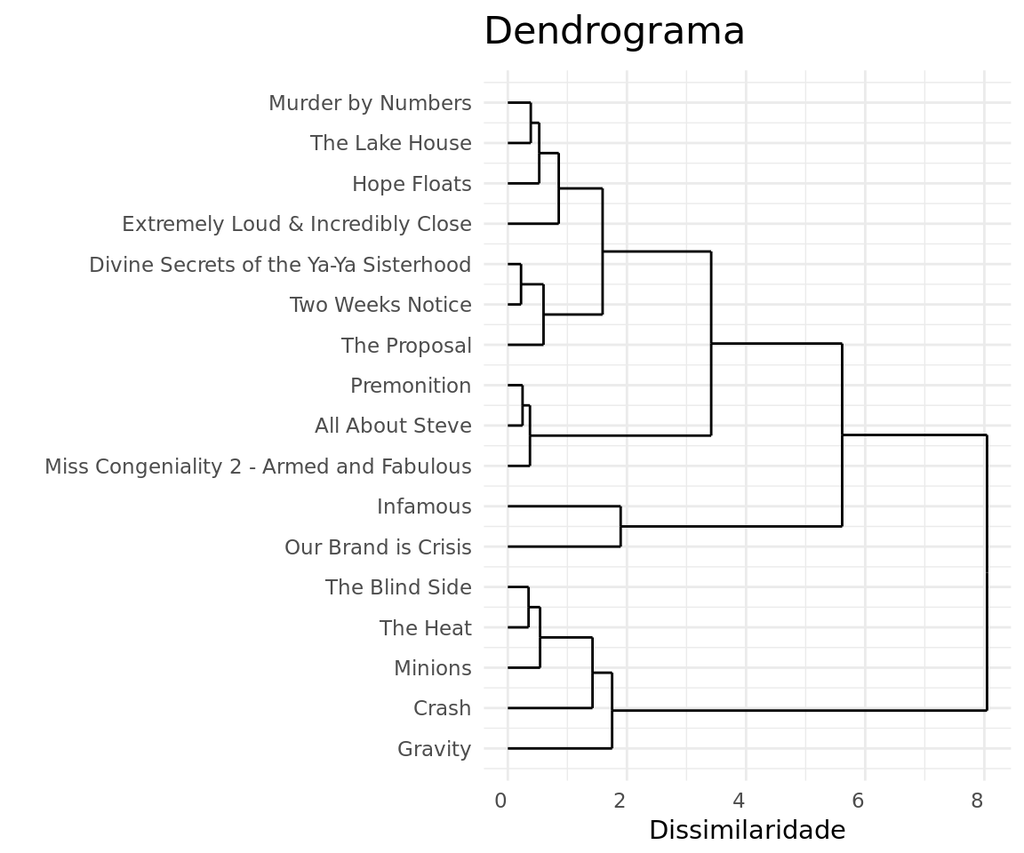

```r
agrupamento_h <- filmes %>%
    mutate(bilheteria =  log10(bilheteria))%>%
    mutate_at(vars(avaliacao, bilheteria), funs(scale)) %>%
    as.data.frame()%>%
    column_to_rownames("filme") %>%
    select(avaliacao, bilheteria) %>%
    dist(method = "euclidian") %>%
    hclust(method = "ward.D")

ggdendrogram(agrupamento_h, rotate = T, size = 2, theme_dendro = F) +
    labs(y = "Dissimilaridade", x = "", title = "Dendrograma")
```

Para melhor observar os agrupamentos e nos ajudar a guiar a melhor escolha mostramos os agrupamentos de 1 a 6 Aqui confirmamos que o grupo 4 é a melhor opção pois, a organização da nuvem de pontos é mais “isolada”e podemos separar visualmente os grupos onde não existe uma miscigenação entre os pontos (observem as cores).

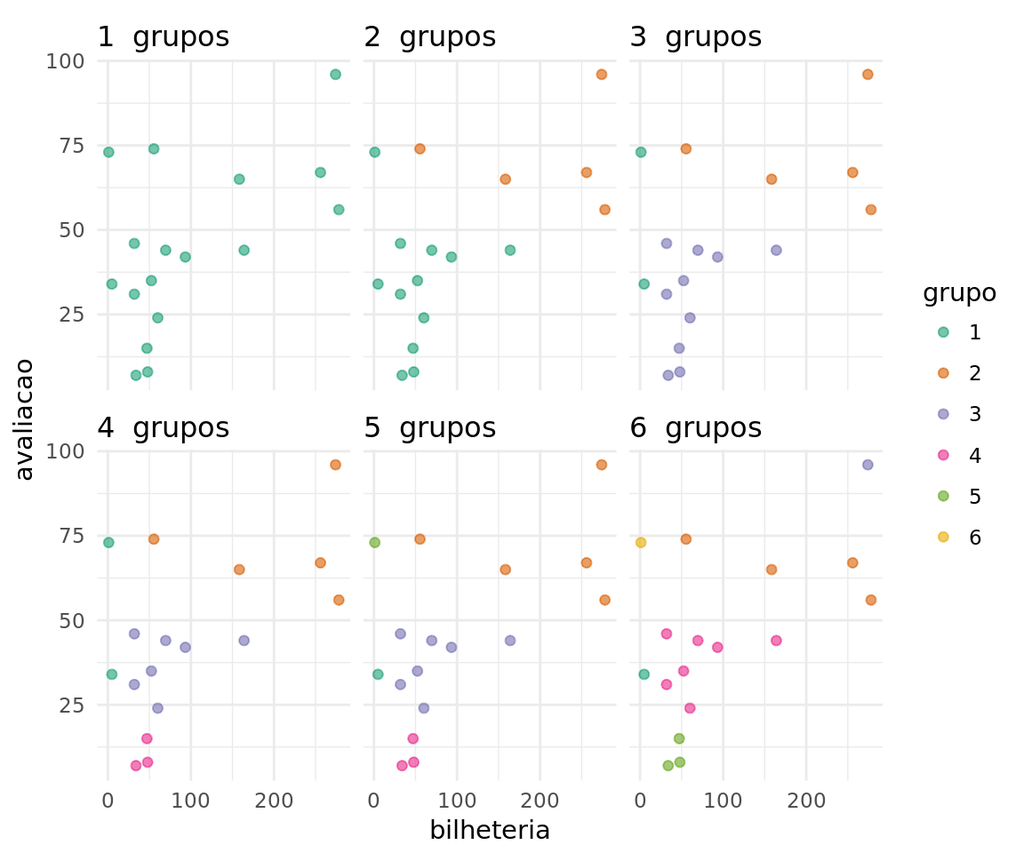

```r
get_grupos <- function(agrupamento, num_grupos){
    agrupamento %>%
        cutree(num_grupos) %>%
        as.data.frame() %>%
        mutate(label = rownames(.)) %>%
        gather(key =  "k", value = "grupo", -label) %>%
        mutate(grupo = as.character(grupo))
}

atribuicoes = get_grupos(agrupamento_h, num_grupos = 1:6)

atribuicoes = atribuicoes %>%
    left_join(filmes, by = c("label" = "filme"))

atribuicoes %>%
    ggplot(aes(x = bilheteria, y = avaliacao, colour = grupo)) +
    geom_jitter(width = .02, height = 0, size = 1.6, alpha = .6) +
    facet_wrap(~ paste(k, " grupos")) +
    scale_color_brewer(palette = "Dark2")
```

## Grupos

Os 4 grupos que temos são: Péssima bilheteria e Boa avaliação, Boa bilheteria e Boa avaliação, Boa bilheteria e Péssima avaliação e Péssima bilheteria e Péssima avaliação.

## A descrição dos grupos é a seguinte :

# Grupo 01 - Péssima bilheteria e Boa avaliação

A bilheteria nesse grupo varia entre: 1.1 e 4.9 A avaliação nesse grupo varia entre: 34 e 73

Como representantes temos : Infamous - 1.1 bilheteria e 73 avaliação Our Brand is Crisis - 4.9 bilheteria e 34 avaliação

# Grupo 02 - Boa bilheteria e Boa avaliação

A bilheteria nesse grupo varia entre : 278.0 - 55.4 A avaliação nesse grupo varia entre: 96 - 56

Como representantes temos : Gravity - 274.1 bilheteria e 96 avaliação  
Minions - 278.0 bilheteria e 56 avaliação

# Grupo 03 - Boa Bilheteria e Péssima Avaliação

A bilheteria nesse grupo varia entre : 164.0 - 31.9 A avaliação nesse grupo varia entre: 46 - 24

Como representantes temos : The Proposal - 164.0 bilheteria e 44 avaliação Hope Floats - 60.1bilheteria e 24 avaliação

# Grupo 04 - Péssima Bilheteria e Péssima Avaliação

A bilheteria nesse grupo varia entre : 47.9 - 33.9 A avaliação nesse grupo varia entre: 15 - 7

Como representantes temos : Premonition - 47.9 bilheteria e 8 avaliação All About Steve - 33.9 bilheteria e 7 avaliação

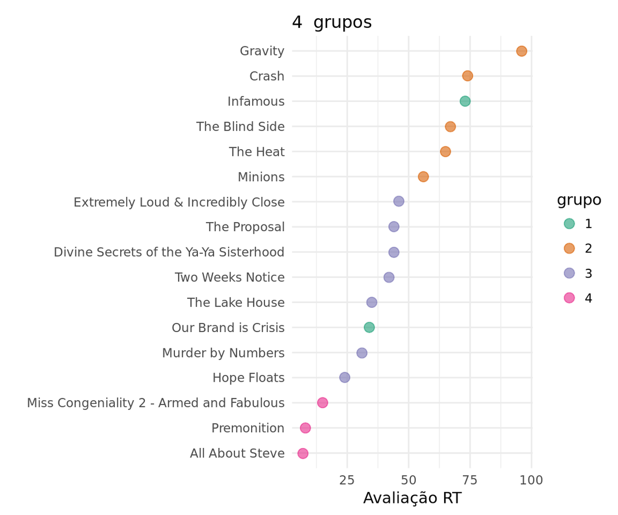

```r
k_escolhido = 4

 atribuicoes %>%
    filter(k == k_escolhido) %>%
    ggplot(aes(x = reorder(label, avaliacao), y = avaliacao, colour = grupo)) +
    geom_jitter(width = .02, height = 0, size = 3, alpha = .6) +
    facet_wrap(~ paste(k, " grupos")) +
    scale_color_brewer(palette = "Dark2") +
    labs(x = "", y = "Avaliação RT") +
    coord_flip()
```